# 6th Project : Investigate a Dataset

## 1. Introduction

I choose Appointment-no-show data set for project. as you know this data set focused on the question of whether or not patients show up for appointment.

Usually, a lot of study has shown that high risk patients also tend to miss their appintment. so I will explore what factors are related to their behavior and analyze patterns in data set.

## 2. Import data set

```python
import pandas as pd
import numpy as np
import matplotlib.pyplot as plt
from datetime import datetime as dt
import seaborn as sns
import matplotlib as mpl

%matplotlib inline
```

```python
data_patient= pd.read_csv('KaggleV2-May-2016.csv')
```

```python
data_patient.head()
```

|  | PatientId | AppointmentID | Gender | ScheduledDay | AppointmentDay | Age | Neighbourhood | Scholarship | Hipertension | Diabetes | Alcoholism | Handcap | SMS_received | No-show |
| --- | --- | --- | --- | --- | --- | --- | --- | --- | --- | --- | --- | --- | --- | --- |
| 0 | 2.987250e+13 | 5642903 | F | 2016-04-29T18:38:08Z | 2016-04-29T00:00:00Z | 62 | JARDIM DA PENHA | 0 | 1 | 0 | 0 | 0 | 0 | No |
| 1 | 5.589978e+14 | 5642503 | M | 2016-04-29T16:08:27Z | 2016-04-29T00:00:00Z | 56 | JARDIM DA PENHA | 0 | 0 | 0 | 0 | 0 | 0 | No |
| 2 | 4.262962e+12 | 5642549 | F | 2016-04-29T16:19:04Z | 2016-04-29T00:00:00Z | 62 | MATA DA PRAIA | 0 | 0 | 0 | 0 | 0 | 0 | No |
| 3 | 8.679512e+11 | 5642828 | F | 2016-04-29T17:29:31Z | 2016-04-29T00:00:00Z | 8 | PONTAL DE CAMBURI | 0 | 0 | 0 | 0 | 0 | 0 | No |
| 4 | 8.841186e+12 | 5642494 | F | 2016-04-29T16:07:23Z | 2016-04-29T00:00:00Z | 56 | JARDIM DA PENHA | 0 | 1 | 1 | 0 | 0 | 0 | No |

```python
data_patient.describe()
```

|  | PatientId | AppointmentID | Age | Scholarship | Hipertension | Diabetes | Alcoholism | Handcap | SMS_received |
| --- | --- | --- | --- | --- | --- | --- | --- | --- | --- |
| count | 1.105270e+05 | 1.105270e+05 | 110527.000000 | 110527.000000 | 110527.000000 | 110527.000000 | 110527.000000 | 110527.000000 | 110527.000000 |
| mean | 1.474963e+14 | 5.675305e+06 | 37.088874 | 0.098266 | 0.197246 | 0.071865 | 0.030400 | 0.022248 | 0.321026 |
| std | 2.560949e+14 | 7.129575e+04 | 23.110205 | 0.297675 | 0.397921 | 0.258265 | 0.171686 | 0.161543 | 0.466873 |
| min | 3.921784e+04 | 5.030230e+06 | -1.000000 | 0.000000 | 0.000000 | 0.000000 | 0.000000 | 0.000000 | 0.000000 |
| 25% | 4.172614e+12 | 5.640286e+06 | 18.000000 | 0.000000 | 0.000000 | 0.000000 | 0.000000 | 0.000000 | 0.000000 |
| 50% | 3.173184e+13 | 5.680573e+06 | 37.000000 | 0.000000 | 0.000000 | 0.000000 | 0.000000 | 0.000000 | 0.000000 |
| 75% | 9.439172e+13 | 5.725524e+06 | 55.000000 | 0.000000 | 0.000000 | 0.000000 | 0.000000 | 0.000000 | 1.000000 |
| max | 9.999816e+14 | 5.790484e+06 | 115.000000 | 1.000000 | 1.000000 | 1.000000 | 1.000000 | 4.000000 | 1.000000 |

### Dependent variable & Independent variable

Dependent variable : No_show

Independent variable : Age, ScheduledDay , AppointmentDay, Neighbourhood , Scholarship, Hipertension, Diabetes Alcoholism , Handcap , SMS_received

### Boolean & Categorical variavle

Boolean : Diabetes, Alcoholism, Hypertension, SMS_received, Scholarship

Categorical : Gender, Handicap, Neighborhood

## 3. Data Cleaning

### 3-1. Investigating Data

```python
# Check the unique value of variables

print ('Gender : ', sorted(data_patient.Gender.unique()))
print

first_schedule = sorted(data_patient.ScheduledDay)
last_schedule = sorted(data_patient.ScheduledDay,reverse=True)

print ('First-ScheduledDay : ',first_schedule[0])
print ('Last-ScheduledDay : ',last_schedule[0])
print

first_appoint = sorted(data_patient.AppointmentDay)
last_appint = sorted(data_patient.AppointmentDay,reverse=True)

print ('First-AppointmentDay :',first_appoint[0])
print ('Last-AppintmentDay : ',last_appint[0])
print
print ('Age : ', sorted(data_patient.Age.unique()))
print
print ('Alcoholism : ', sorted(data_patient.Alcoholism.unique()))
print
print ('Diabetes : ', sorted(data_patient.Diabetes.unique()))
print
print ('Handcap : ', sorted(data_patient.Handcap.unique()))
print
print ('Hipertention : ',sorted(data_patient.Hipertension.unique()))
print
print ('Scholarship : ', sorted(data_patient.Scholarship.unique()))
print
print ('SMS_received : ', sorted(data_patient.SMS_received.unique()))
```

```
('Gender : ', ['F', 'M'])

('First-ScheduledDay : ', '2015-11-10T07:13:56Z')
('Last-ScheduledDay : ', '2016-06-08T20:07:23Z')

('First-AppointmentDay :', '2016-04-29T00:00:00Z')
('Last-AppintmentDay : ', '2016-06-08T00:00:00Z')

('Age : ', [-1, 0, 1, 2, 3, 4, 5, 6, 7, 8, 9, 10, 11, 12, 13, 14, 15, 16, 17, 18, 19, 20, 21, 22, 23, 24, 25, 26, 27, 28, 29, 30, 31, 32, 33, 34, 35, 36, 37, 38, 39, 40, 41, 42, 43, 44, 45, 46, 47, 48, 49, 50, 51, 52, 53, 54, 55, 56, 57, 58, 59, 60, 61, 62, 63, 64, 65, 66, 67, 68, 69, 70, 71, 72, 73…

('Alcoholism : ', [0, 1])

('Diabetes : ', [0, 1])

('Handcap : ', [0, 1, 2, 3, 4])

('Hipertention : ', [0, 1])

('Scholarship : ', [0, 1])

('SMS_received : ', [0, 1])
```

```python
#check type of data for parsing

data_patient.info()
```

```
<class 'pandas.core.frame.DataFrame'>
RangeIndex: 110527 entries, 0 to 110526
Data columns (total 14 columns):
PatientId         110527 non-null float64
AppointmentID     110527 non-null int64
Gender            110527 non-null object
ScheduledDay      110527 non-null object
AppointmentDay    110527 non-null object
Age               110527 non-null int64
Neighbourhood     110527 non-null object
Scholarship       110527 non-null int64
Hipertension      110527 non-null int64
Diabetes          110527 non-null int64
Alcoholism        110527 non-null int64
Handcap           110527 non-null int64
SMS_received      110527 non-null int64
No-show           110527 non-null object
dtypes: float64(1), int64(8), object(5)
memory usage: 11.8+ MB
```

```python
# If there are null valuse then return True

data_patient.columns.isnull()
```

```
array([False, False, False, False, False, False, False, False, False,
       False, False, False, False, False], dtype=bool)
```

```python
# If age is -1 and more than 100 then remove the values

data_patient=data_patient[(data_patient['Age'] >= 0) & (data_patient['Age'] < 100)]
```

```python
print ('Age : ', sorted(data_patient.Age.unique()))
```

```
('Age : ', [0, 1, 2, 3, 4, 5, 6, 7, 8, 9, 10, 11, 12, 13, 14, 15, 16, 17, 18, 19, 20, 21, 22, 23, 24, 25, 26, 27, 28, 29, 30, 31, 32, 33, 34, 35, 36, 37, 38, 39, 40, 41, 42, 43, 44, 45, 46, 47, 48, 49, 50, 51, 52, 53, 54, 55, 56, 57, 58, 59, 60, 61, 62, 63, 64, 65, 66, 67, 68, 69, 70, 71, 72, 73, 74…
```

### 3-2. Parsing data type

##### Trassfer dates to datetime

```python
data_patient['Appointment_Day'] = pd.to_datetime(data_patient['AppointmentDay'], format='%Y-%m-%d')
```

```python
data_patient['Registration_Date'] = data_patient.ScheduledDay.str.split('T').str[0]
```

```python
data_patient['set_up_Appointment'] = pd.to_datetime(data_patient['Registration_Date'], format='%Y-%m-%d')
```

```python
#Days = data_patient[['set_up_Appointment','Appointment_Day']]
#Days.head()
```

##### Create new columns : Diff_day

Difference with their appointment and set up appointment days.

```python
data_patient['Diff_day'] = data_patient['Appointment_Day'] - data_patient['set_up_Appointment']
data_patient['Diff_day'] = data_patient.Diff_day.dt.days
```

##### Modifying 'No-show' to status

Be careful about that it says ‘No’ if the patient showed up to their appointment, and ‘Yes’ if they did not show up.

```python
def transfer_status(noshow):
    if noshow == 'No':
        return 'show_up'
    else:
        return 'missed'
```

```python
data_patient['No-show']= data_patient['No-show'].apply(transfer_status)
```

##### Grouping Age

```python
def Agegroups(age):
    if age <10 :
        return 'kids'
    elif age >=10 and age <= 19:
        return 'Teenager'
    elif age >= 20 and age <=29:
        return 'twenty years'
    elif age >= 30 and age <=39:
        return 'thirty years'
    elif age >= 40 and age <=49:
        return 'forty years'
    elif age >= 50 and age <=59:
        return 'fifty years'
    else:
        return 'Seniors'
```

```python
data_patient['Age_group']= data_patient['Age'].apply(Agegroups)
```

#### Renaming column name

```python
data_patient.rename(columns={'No-show' : 'medical_checkup'},inplace=True)
```

#### Identifying Gender Percentage by No-show

```python
def percentage_noshow(data,group_by):
    df = pd.crosstab(index = data[group_by],columns = data.medical_checkup).reset_index()
    df['Percentage'] = (df['show_up']/(df['show_up']+df['missed']))*100
    return df[[group_by,'Percentage']]
```

```python
percen_data = percentage_noshow(data_patient,'Gender')
percen_data
```

| medical_checkup | Gender | Percentage |
| --- | --- | --- |
| 0 | F | 79.68676 |
| 1 | M | 80.03102 |

### 3-3. Delete unwanted columns

```python
data_patient.drop(columns='AppointmentID',inplace=True)
data_patient.drop(columns='PatientId',inplace=True)
data_patient.drop(columns='ScheduledDay',inplace=True)
data_patient.drop(columns='AppointmentDay',inplace=True)
data_patient.drop(columns='Registration_Date',inplace=True)
```

```python
data_patient.head(10)
```

|  | Gender | Age | Neighbourhood | Scholarship | Hipertension | Diabetes | Alcoholism | Handcap | SMS_received | medical_checkup | Appointment_Day | set_up_Appointment | Diff_day | Age_group |
| --- | --- | --- | --- | --- | --- | --- | --- | --- | --- | --- | --- | --- | --- | --- |
| 0 | F | 62 | JARDIM DA PENHA | 0 | 1 | 0 | 0 | 0 | 0 | show_up | 2016-04-29 | 2016-04-29 | 0 | Seniors |
| 1 | M | 56 | JARDIM DA PENHA | 0 | 0 | 0 | 0 | 0 | 0 | show_up | 2016-04-29 | 2016-04-29 | 0 | fifty years |
| 2 | F | 62 | MATA DA PRAIA | 0 | 0 | 0 | 0 | 0 | 0 | show_up | 2016-04-29 | 2016-04-29 | 0 | Seniors |
| 3 | F | 8 | PONTAL DE CAMBURI | 0 | 0 | 0 | 0 | 0 | 0 | show_up | 2016-04-29 | 2016-04-29 | 0 | kids |
| 4 | F | 56 | JARDIM DA PENHA | 0 | 1 | 1 | 0 | 0 | 0 | show_up | 2016-04-29 | 2016-04-29 | 0 | fifty years |
| 5 | F | 76 | REPÚBLICA | 0 | 1 | 0 | 0 | 0 | 0 | show_up | 2016-04-29 | 2016-04-27 | 2 | Seniors |
| 6 | F | 23 | GOIABEIRAS | 0 | 0 | 0 | 0 | 0 | 0 | missed | 2016-04-29 | 2016-04-27 | 2 | twenty years |
| 7 | F | 39 | GOIABEIRAS | 0 | 0 | 0 | 0 | 0 | 0 | missed | 2016-04-29 | 2016-04-27 | 2 | thirty years |
| 8 | F | 21 | ANDORINHAS | 0 | 0 | 0 | 0 | 0 | 0 | show_up | 2016-04-29 | 2016-04-29 | 0 | twenty years |
| 9 | F | 19 | CONQUISTA | 0 | 0 | 0 | 0 | 0 | 0 | show_up | 2016-04-29 | 2016-04-27 | 2 | Teenager |

## 4. Exploratory Data Analysis

### Q1. What is the percentage of no_show variable among the popluation?

```python
import pylab

count_noshow = data_patient['medical_checkup'].value_counts()
print count_noshow
```

```
show_up    88199
missed     22316
Name: medical_checkup, dtype: int64
```

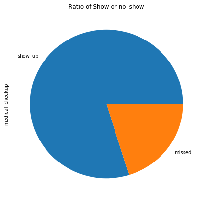

```python
pylab.subplots(figsize=(7,7))
data_patient['medical_checkup'].value_counts().plot(kind='pie',title='Ratio of Show or no_show')
plt.show()
```

: Total patient attendence for scheduled appoinment in data set is 110,527. Approximately 20% of all appointment is no-show data.

### Q2. What factors are important for us to know in order to predict if a patient will no_show for appointment?

#### Filtering missed data

```python
# Making new dataframe
no_show_sample=data_patient[data_patient.medical_checkup=='missed']
```

```python
data={
    "Hipertension":no_show_sample.Hipertension,
    "Diabetes":no_show_sample.Diabetes,
    "Alcoholism":no_show_sample.Alcoholism,
    "Handcap":no_show_sample.Handcap,
    "Scholarship":no_show_sample.Scholarship,
    "SMS_received":no_show_sample.SMS_received,
    "Age_group":no_show_sample.Age_group,
    "Age":no_show_sample.Age,
    "Appointment_Day":no_show_sample.Appointment_Day,
    "waiting_day": no_show_sample.Diff_day,
    "no_show": no_show_sample.medical_checkup
}
columuns = ['Hipertension','Diabetes','Alcoholism','Handcap','Scholarship','SMS_received','Age_group','Age','Appointment_Day','waiting_day','no_show']
medical_data_2=pd.DataFrame(data,columns=columuns)
```

```python
medical_data_2.head() # Dataframe for Question
```

|  | Hipertension | Diabetes | Alcoholism | Handcap | Scholarship | SMS_received | Age_group | Age | Appointment_Day | waiting_day | no_show |
| --- | --- | --- | --- | --- | --- | --- | --- | --- | --- | --- | --- |
| 6 | 0 | 0 | 0 | 0 | 0 | 0 | twenty years | 23 | 2016-04-29 | 2 | missed |
| 7 | 0 | 0 | 0 | 0 | 0 | 0 | thirty years | 39 | 2016-04-29 | 2 | missed |
| 11 | 0 | 0 | 0 | 0 | 0 | 1 | twenty years | 29 | 2016-04-29 | 3 | missed |
| 17 | 0 | 0 | 0 | 0 | 1 | 0 | forty years | 40 | 2016-04-29 | 1 | missed |
| 20 | 0 | 0 | 0 | 0 | 0 | 0 | thirty years | 30 | 2016-04-29 | 2 | missed |

#### 1 : Medical conditions

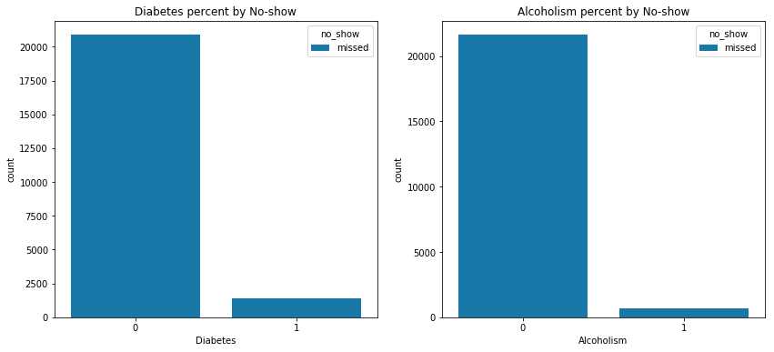

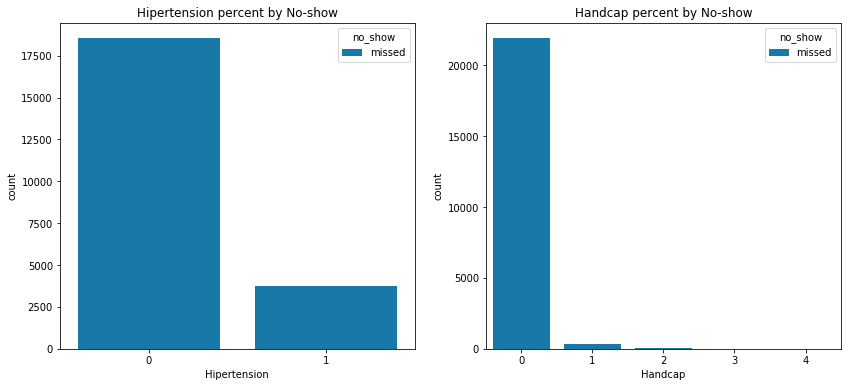

```python
fig1=plt.figure(figsize=(14,6))
ax=fig1.add_subplot(1,2,1) # 1
sns.countplot(x="Diabetes",hue="no_show",data=medical_data_2,palette='winter')
plt.title('Diabetes percent by No-show')

ax=fig1.add_subplot(1,2,2)
sns.countplot(x="Alcoholism",hue="no_show",data=medical_data_2,palette='winter')
plt.title('Alcoholism percent by No-show')
plt.show()

fig2=plt.figure(figsize=(14,6))
ax=fig2.add_subplot(1,2,1) # 2
sns.countplot(x="Hipertension",hue="no_show",data=medical_data_2,palette='winter')
plt.title('Hipertension percent by No-show')

ax=fig2.add_subplot(1,2,2)
sns.countplot(x="Handcap",hue="no_show",data=medical_data_2,palette='winter')
plt.title('Handcap percent by No-show')
plt.show()
```

#### 2 : Gender

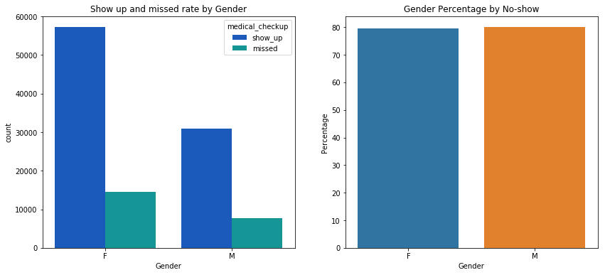

```python
fig3=plt.figure(figsize=(14,6))# 3
ax=fig3.add_subplot(1,2,1)
sns.countplot(x="Gender",hue="medical_checkup",data=data_patient,palette='winter')
plt.title('Show up and missed rate by Gender')

ax=fig3.add_subplot(1,2,2)
sns.barplot(x = 'Gender', y = 'Percentage', data = percen_data)
plt.title('Gender Percentage by No-show')
plt.show()
```

: In the left chart, female is nearly double than male. However in the percentage of missed data approximately both are same. So, There's no difference between female and male for no_show rate.

#### 3 : Scholarship , SMS_received

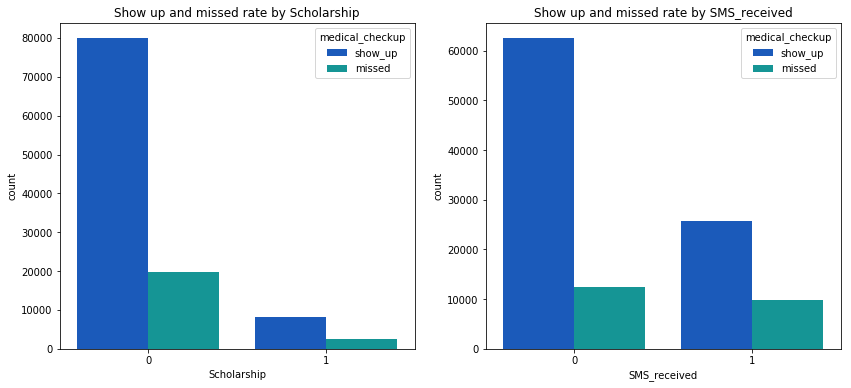

```python
fig4=plt.figure(figsize=(14,6))# 4

ax=fig4.add_subplot(1,2,1)
sns.countplot(x="Scholarship",hue="medical_checkup",data=data_patient,palette='winter')
plt.title('Show up and missed rate by Scholarship')

ax=fig4.add_subplot(1,2,2)
sns.countplot(x="SMS_received",hue="medical_checkup",data=data_patient,palette='winter')
plt.title('Show up and missed rate by SMS_received')
plt.show()
```

#### 4 : Age

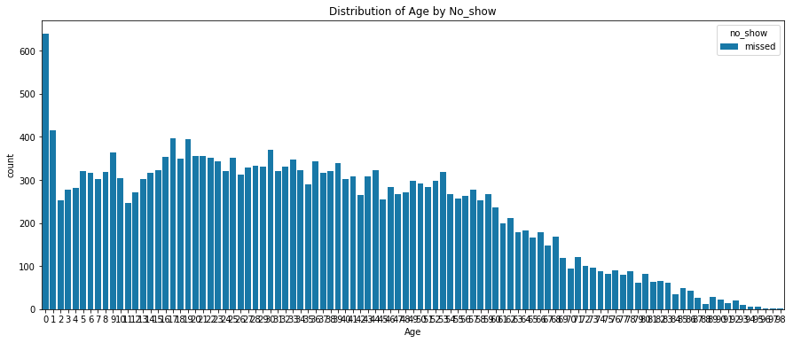

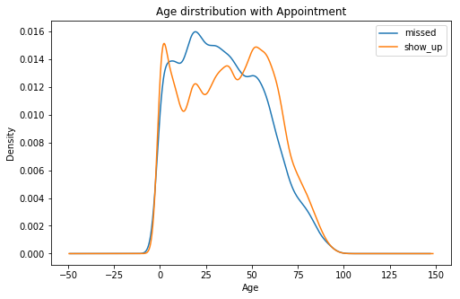

```python
pylab.subplots(figsize=(15, 6))
sns.countplot(x="Age",hue="no_show",data=medical_data_2,palette='winter')
plt.title('Distribution of Age by No_show')
plt.show()

pylab.subplots(figsize=(8, 5))
data_patient.Age[data_patient['medical_checkup'] == 'missed'].plot(kind='kde')
data_patient.Age[data_patient['medical_checkup'] == 'show_up'].plot(kind='kde')
plt.xlabel('Age')
plt.title('Age dirstribution with Appointment')
plt.legend(('missed','show_up'),loc='best')
plt.show()
```

: Largest number of patient do appear to be the youngest. Specially 0-years olds are very high. However, 0-years olds appear to be very high in Show_up data. Anyway, Youngest rate remains constant into the oldest ages but this rate is slowly decreased.

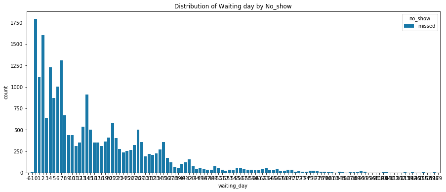

```python
pylab.subplots(figsize=(15, 6))
sns.countplot(x="waiting_day",hue="no_show",data=medical_data_2,palette='winter')
plt.title('Distribution of Waiting day by No_show')
plt.show()
```

```python
medical_data_2.waiting_day.describe() # Summary waiting_day by no_show
```

```
count    22316.000000
mean        15.831645
std         16.605921
min         -6.000000
25%          4.000000
50%         11.000000
75%         23.000000
max        179.000000
Name: waiting_day, dtype: float64
```

: Based on the Statistics summary, longest waiting day is 179 days and average of waiting day is 15 days. Also, above histogram is positive skewed.

## 5. Conclusion

: I analyzed what factors are most important variables for no show. based on this analysis, approximately 20% do not show up on the appointment. And I found that Age, SMS and the number of days between setting the appointment and the actual appointment. In thsi analysis, I call that Waiting day. the longest waiting day is 179 days and median is 11 days. Average of waiting day is 15 days. Particularly, from 0 to 15 days are very high.

## 6. Limitation

Also, if there are some useful information like patient's Average income and location, weather conditions. these variables could be good source for analyze No-show rate. For instance, maybe rich people more often visit their doctor. On the other hand, poor meet rarely the doctor. it would be meaningful information for analysis.